# Inter-Integrated Circuit

## Activity Objective

- Implement an inter-integrated circuit (I2C) communication bus
- Analyze the implemented I2C communication bus with an oscilloscope

## Equipment Needed

- (C) Benchtop oscilloscope
- (S) Two Arduinos
- (S) A few jumper wires

(C) - In classroom, (I) - provided by instructor, (S) - provided by student or in kit

## Activity Procedure

The following procedure is intended to be used with the Siglent SDS 1202X-E oscilloscope. Deviations from the steps listed below may have to be taken when using a different oscilloscope.

1. Partner with a classmate and decide whose Arduino will be the controller and peripheral.
2. Connect the SCL pin, SDA pin, and a ground pin of the two Arduinos to each other.
3. For the Arduino designated as the controller, upload the sketch `master_writer` sketch found at `File > Examples > Wire`.
4. For the Arduino designated as the peripheral, upload the sketch `slave_receiver` sketch found at `File > Examples > Wire`.
5. Open the serial monitor for the Arduino designated as the peripheral and check to see if the information sent from the Arduino designated as the controller is being displayed.
6. Connect the channel 1 of the oscilloscope to the SCL and ground line of the I2C communication bus.
7. Connect the channel 2 of the oscilloscope to the SDA and ground line of the I2C communication bus.

**Remember**

The ground of the oscilloscope probe is the alligator clip.

8. Enable the Decode button on the oscilloscope.
9. For the menu that appears at the bottom of the oscilloscope’s screen, select I2C for the Protocol. It should be the second from the left menu item.
10. Make sure the Display On option is selected. It should be the second from the right menu item.
11. Select the Signal option. It should be the third from the left menu item.
12. Within the Signal menu option, ensure the SCL and SDA are set to the appropriate channels and the threshold voltages for each are approximately $1.7 V$.
13. Exit the Signal menu option by selecting the curve arrow located at the right most menu option.
14. Select the NextPage menu option. It should be the right most menu option.
15. Ensure the Format is set to ASCII.
16. Press the Normal button of the oscilloscope located in the Trigger section on the front panel.
17. Set the trigger level to approximately $1.7 V$ by adjusting the Level knob in the Trigger section on the front panel.
18. Adjust the vertical and horizontal scale and position so that the SCL and SDA signals are positioned approximately as shown in Figure 1.

Figure 1: SCL (top) and SDA (bottom) signals

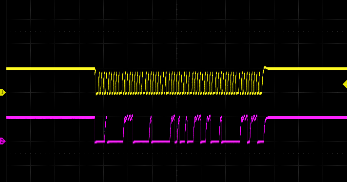

19. At this point, the transmitted information should be display in between the signal window and the menu at the bottom of the oscilloscope’s screen. If that is the case, raise your hand and allow the instructor to inspect your system. Be prepared to answer any questions pertaining to how the data is being displayed.

## Assignment

After completing the procedure, complete a memo detailing the conducted lab. Submission should be made on Canvas by the beginning of class on Mo 4-22.